# Changing funnel plot options

## Changing labels

You can change the plot labels and axis labels easily using the options: `title`, `x_label` and `y_label`.

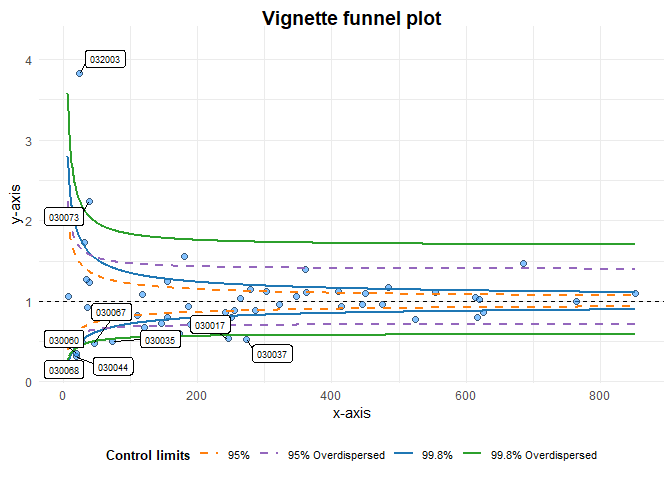

```
#> A funnel plot object with 54 points of which 9 are outliers.
#> Plot is adjusted for overdispersion.
```

```r
funnel_plot(medpar, denominator = prds, numerator = los
            , group = provnum, limit = 99, label = "outlier"
            , draw_unadjusted = TRUE, title = "Vignette funnel plot"
            , x_label = "x-axis", y_label = "y-axis")
```

There are different labelling options for the data points too, using the `label` option. The default is to label outliers, but you can turn labels off, label the highlighted points, or both the highlighted points and the outliers (‘both’)

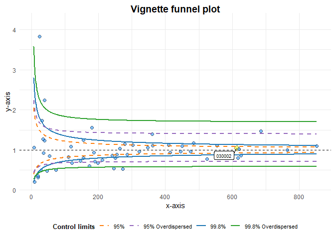

```
#> A funnel plot object with 54 points of which 9 are outliers.
#> Plot is adjusted for overdispersion.
```

```r
funnel_plot(medpar, denominator = prds, numerator = los
            , group = provnum, limit = 99
            , draw_unadjusted = TRUE, title = "Vignette funnel plot"
            , x_label = "x-axis", y_label = "y-axis"
            , highlight = "030002", label = "highlight")
```

## Cutting out the ggplot object

Since `FunnelPlotR` uses `ggplot2`, you could always extract the plot and alter it manually like any other `ggplot2` object. The easiest way is to extract it with `plot()`. Below we’ll add a (completely useless) vertical line to demonstrate adding more elements:

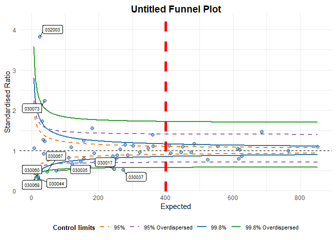

```r
# Original funnel plot object
fp <-
  funnel_plot(medpar, denominator = prds, numerator = los
              , group = provnum, limit = 99, label = "outlier"
              , draw_unadjusted = TRUE)

# Extract just the plot
my_plot <- plot(fp)

# Add an additional geom to plot
my_plot +
  geom_vline(aes(xintercept = 400), linetype = "dashed"
             , colour = "red", linewidth = 2)
```